# Data 698 Project

#### 2021

| **No** | **Variable** | **Stats / Values** | **Freqs (% of Valid)** | **Graph** | **Valid** | **Missing** |
| --- | --- | --- | --- | --- | --- | --- |
| 1 | schooldbn [character] | 1. 01M034 2. 01M140 3. 01M184 4. 01M188 5. 01M332 6. 01M378 7. 01M450 8. 01M539 9. 01M839 10. 02M104 [ 448 others ] | 1 ( 0.2% ) 1 ( 0.2% ) 1 ( 0.2% ) 1 ( 0.2% ) 1 ( 0.2% ) 1 ( 0.2% ) 1 ( 0.2% ) 1 ( 0.2% ) 1 ( 0.2% ) 1 ( 0.2% ) 448 ( 97.8% ) |  | 458 (100.0%) | 0 (0.0%) |
| 2 | district [numeric] | Mean (sd) : 16 (9.4) min ≤ med ≤ max: 1 ≤ 15 ≤ 32 IQR (CV) : 16 (0.6) | 32 distinct values |  | 458 (100.0%) | 0 (0.0%) |
| 3 | name [character] | 1. Academy for College Prepa 2. Academy for New Americans 3. Academy For Personal Lead 4. Academy for Young Writers 5. Academy of Applied Mathem 6. Academy of Arts and Lette 7. Academy of Medical Tech… | 1 ( 0.2% ) 1 ( 0.2% ) 1 ( 0.2% ) 1 ( 0.2% ) 1 ( 0.2% ) 1 ( 0.2% ) 1 ( 0.2% ) 1 ( 0.2% ) 1 ( 0.2% ) 1 ( 0.2% ) 448 ( 97.8% ) |  | 458 (100.0%) | 0 (0.0%) |
| 4 | year [numeric] | 1 distinct value | 2021 : 458 ( 100.0% ) |  | 458 (100.0%) | 0 (0.0%) |
| 5 | coursepassrate [numeric] | Mean (sd) : 91.7 (8.8) min ≤ med ≤ max: 39 ≤ 94 ≤ 100 IQR (CV) : 9.8 (0.1) | 41 distinct values |  | 458 (100.0%) | 0 (0.0%) |
| 6 | accessibility [character] | 1. Fully Accessible 2. Not Accessible 3. Partially Accessible | 124 ( 27.1% ) 184 ( 40.2% ) 150 ( 32.8% ) |  | 458 (100.0%) | 0 (0.0%) |
| 7 | elaprof [numeric] | Mean (sd) : 43.4 (21) min ≤ med ≤ max: 2 ≤ 38 ≤ 100 IQR (CV) : 31.5 (0.5) | 87 distinct values |  | 458 (100.0%) | 0 (0.0%) |
| 8 | mathprof [numeric] | Mean (sd) : 38.6 (23.4) min ≤ med ≤ max: 1 ≤ 33.5 ≤ 100 IQR (CV) : 36 (0.6) | 93 distinct values |  | 458 (100.0%) | 0 (0.0%) |
| 9 | totalstudents [numeric] | Mean (sd) : 625.5 (397.7) min ≤ med ≤ max: 85 ≤ 524.5 ≤ 2265 IQR (CV) : 449 (0.6) | 380 distinct values |  | 458 (100.0%) | 0 (0.0%) |
| 10 | surveysafety [numeric] | Mean (sd) : 82.9 (8.2) min ≤ med ≤ max: 57 ≤ 84 ≤ 100 IQR (CV) : 11 (0.1) | 41 distinct values |  | 457 (99.8%) | 1 (0.2%) |
| 11 | dual_program [numeric] | Min : 0 Mean : 0.1 Max : 1 | 0 : 399 ( 87.1% ) 1 : 59 ( 12.9% ) |  | 458 (100.0%) | 0 (0.0%) |
| 12 | shsat_prep [numeric] | Min : 0 Mean : 0.3 Max : 1 | 0 : 324 ( 70.7% ) 1 : 134 ( 29.3% ) |  | 458 (100.0%) | 0 (0.0%) |
| 13 | student_count [numeric] | Mean (sd) : 139.4 (127.7) min ≤ med ≤ max: 12 ≤ 95 ≤ 764 IQR (CV) : 82.8 (0.9) | 209 distinct values |  | 458 (100.0%) | 0 (0.0%) |
| 14 | testers_count [numeric] | Mean (sd) : 41.4 (59) min ≤ med ≤ max: 0 ≤ 20 ≤ 374 IQR (CV) : 36.8 (1.4) | 121 distinct values |  | 458 (100.0%) | 0 (0.0%) |
| 15 | offers_count [numeric] | Mean (sd) : 7.3 (21.6) min ≤ med ≤ max: 0 ≤ 0 ≤ 221 IQR (CV) : 0 (3) | 49 distinct values |  | 458 (100.0%) | 0 (0.0%) |
| 16 | rate_offers [numeric] | Mean (sd) : 0.1 (0.1) min ≤ med ≤ max: 0 ≤ 0 ≤ 0.8 IQR (CV) : 0 (2.3) | 98 distinct values |  | 458 (100.0%) | 0 (0.0%) |

Generated by summarytools 1.0.0 ([R](https://www.r-project.org/) version 4.1.3)  
2022-05-06

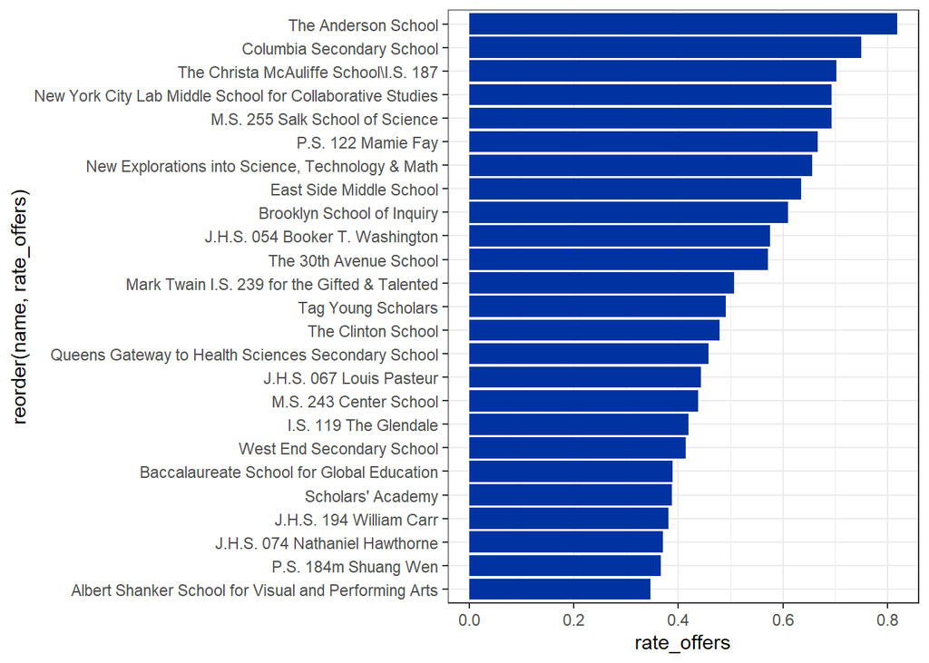

```r
ggplot( head(arrange(schools2021, desc(rate_offers)), n = 25), aes(x= reorder(name, rate_offers), y=rate_offers) ) +
  geom_bar(stat = "identity", fill="#0033a1") +
  coord_flip() +
  theme_bw()
```

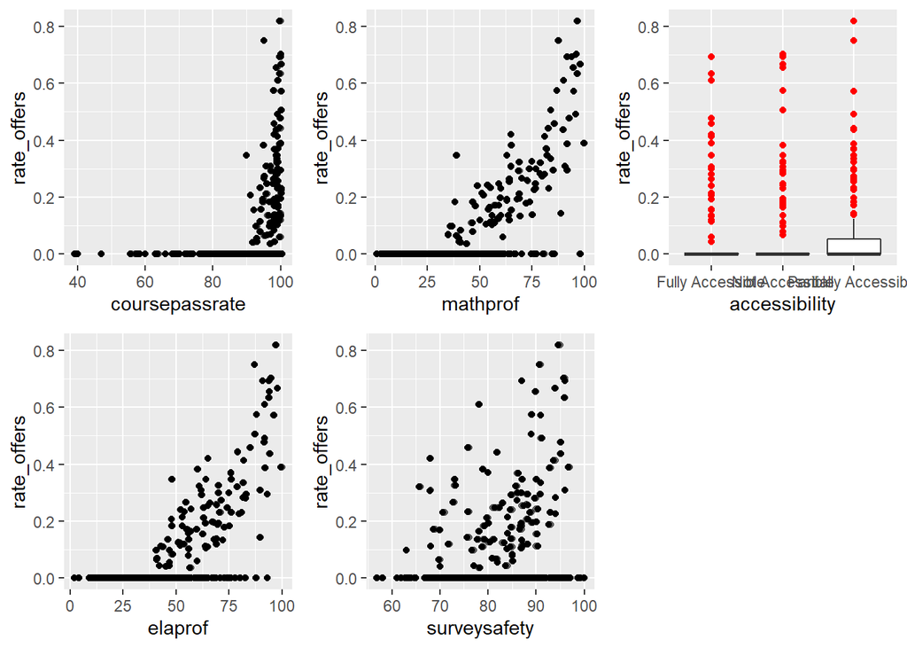

```r
p1 <- ggplot(data=model_data[model_data$year == 2021, ], aes(x=coursepassrate, y=rate_offers)) + geom_point(alpha=0.5) + geom_jitter()
p2 <- ggplot(data=model_data[model_data$year == 2021, ], aes(x=elaprof, y=rate_offers)) + geom_point(alpha=0.5) + geom_jitter()
p3 <- ggplot(data=model_data[model_data$year == 2021, ], aes(x=mathprof, y=rate_offers)) + geom_point(alpha=0.5) + geom_jitter()
p4 <- ggplot(data=model_data[model_data$year == 2021, ], aes(x=surveysafety, y=rate_offers)) + geom_point(alpha=0.5) + geom_jitter()
p5 <- ggplot(data=model_data[model_data$year == 2021, ], aes(x=accessibility, y=rate_offers)) + geom_boxplot() + geom_boxplot(outlier.colour = "red")

multiplot(p1, p2, p3, p4, p5, cols=3)
```

```r
# Cor plots
ggcorr(schools2021[, c(5,7,8,9,10,11,12,13,14,15,16)], label = T, hjust= 0.9)
```

[output not shown]

# Experimentation & Results

After EDA, I will split the data into test and training partitions, this section will go over specific models that were made to predict `count_offers` (the number of offers given to student).

```r
set.seed(505)
data_split <- initial_split(model_data, prop = 0.8, strata = district)
schools_train <- training(data_split)
schools_test <- testing(data_split)
```

## Decision Tree

The following code creates the decision tree.

```r
model_spec <- decision_tree() %>%
  set_mode("regression") %>%
  set_engine("rpart")

model_spec
```

```
## Decision Tree Model Specification (regression)
##
## Computational engine: rpart
```

```r
# Train the model
model <- model_spec %>%
  fit(formula = offers_count ~ dual_program + shsat_prep + testers_count + student_count + elaprof + mathprof + coursepassrate,
      data = schools_train)

# Information about the model
model
```

```
## parsnip model object
##
## n= 1260
##
## node), split, n, deviance, yval
##       * denotes terminal node
##
##  1) root 1260 741467.700   8.4349210
##    2) testers_count< 198 1195 178775.700   4.2702930
##      4) mathprof< 89.5 1161  75592.280   2.9750220
##        8) testers_count< 64.5 982   6799.541   0.6425662 *
##        9) testers_count>=64.5 179  34141.610  15.7709500
##         18) mathprof< 53.5 102   6729.578   9.6960780 *
##         19) mathprof>=53.5 77  18661.450  23.8181800 *
##      5) mathprof>=89.5 34  34722.500  48.5000000
##       10) testers_count< 104.5 24   8484.500  32.2500000 *
##       11) testers_count>=104.5 10   4690.500  87.5000000 *
##    3) testers_count>=198 65 160922.000  85.0000000
##      6) elaprof< 82.5 50  39340.020  63.8600000
##       12) mathprof< 62 18   5906.000  36.0000000 *
##       13) mathprof>=62 32  11603.970  79.5312500 *
##      7) elaprof>=82.5 15  24753.730 155.4667000 *
```

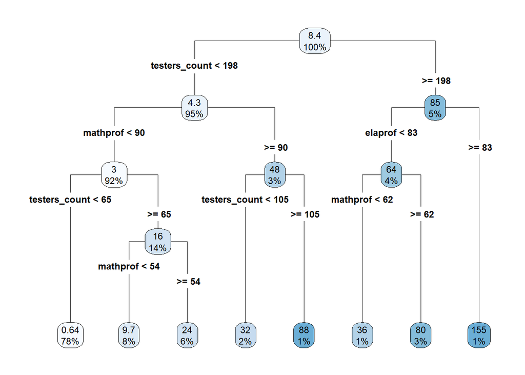

```r
# A plot of the model
model$fit  %>% rpart.plot(type = 4, roundint=FALSE)
```

### Performance of the Tree

After building the decision tree model based upon the variables, we will take the mean square error.

```r
# Declare Mean Absolute Error function
MAE <- function(actual, predicted){
  return(mean(abs(actual - predicted)))
}

# Generate the predictions using the test data
schools_test$dt_model <- (predict(model, new_data = schools_test))$.pred

# Calculate the mean absolute error
mae_decisiontree_model <- MAE(schools_test$offers_count, schools_test$dt_model)


# Calculate the RMSE
decisiontree_rmse <- schools_test %>%
  mutate(residual = dt_model - offers_count) %>%
  summarize(rmse  = sqrt(mean(residual^2)))
```

The mean absolute error of the decision tree is **3.7813729**.  
The RMSE of the decision tree is

| rmse |
| --- |
| 8.481705 |

.

The two features of `dual_program` and `shsat_prep` were removed because they had a negligible correlation measure.

## First Model

This section will build a traditional linear regression model. The training data will be used and then predictions will be run using the testing data set.

```r
first_model <- lm(offers_count ~ testers_count + student_count + elaprof + mathprof + coursepassrate, data=schools_train)
summary(first_model)
```

```
##
## Call:
## lm(formula = offers_count ~ testers_count + student_count + elaprof +
##     mathprof + coursepassrate, data = schools_train)
##
## Residuals:
##     Min      1Q  Median      3Q     Max
## -70.220  -4.714   0.404   4.452 112.338
##
## Coefficients:
##                 Estimate Std. Error t value Pr(>|t|)
## (Intercept)    12.220274   3.895428   3.137  0.00175 **
## testers_count   0.456845   0.012550  36.401  < 2e-16 ***
## student_count  -0.101659   0.005554 -18.304  < 2e-16 ***
## elaprof        -0.061336   0.051486  -1.191  0.23376
## mathprof        0.144781   0.047123   3.072  0.00217 **
## coursepassrate -0.141826   0.045641  -3.107  0.00193 **
## ---
## Signif. codes:  0 '***' 0.001 '**' 0.01 '*' 0.05 '.' 0.1 ' ' 1
##
## Residual standard error: 12.47 on 1254 degrees of freedom
## Multiple R-squared:  0.7372, Adjusted R-squared:  0.7361
## F-statistic: 703.4 on 5 and 1254 DF,  p-value: < 2.2e-16
```

### Performance of First Model

A plot is shown using the model’s prediction and the actual `offers_count`. A RMSE score is also generated.

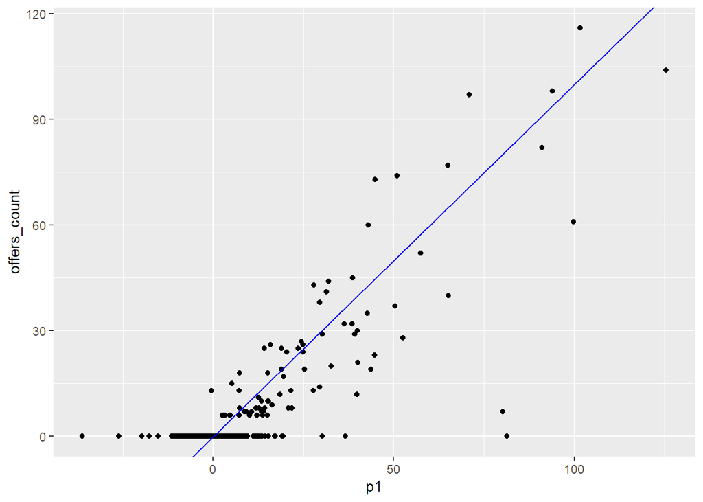

```r
## Use the model on the testing data

## Create the prediction column based on the model
schools_test$p1 <- predict(first_model, newdata=schools_test)

## Plot to compare the predictions to actual prediction on the x axis
ggplot(schools_test, aes(x=p1, y=offers_count)) + geom_point() + geom_abline(color="blue")
```

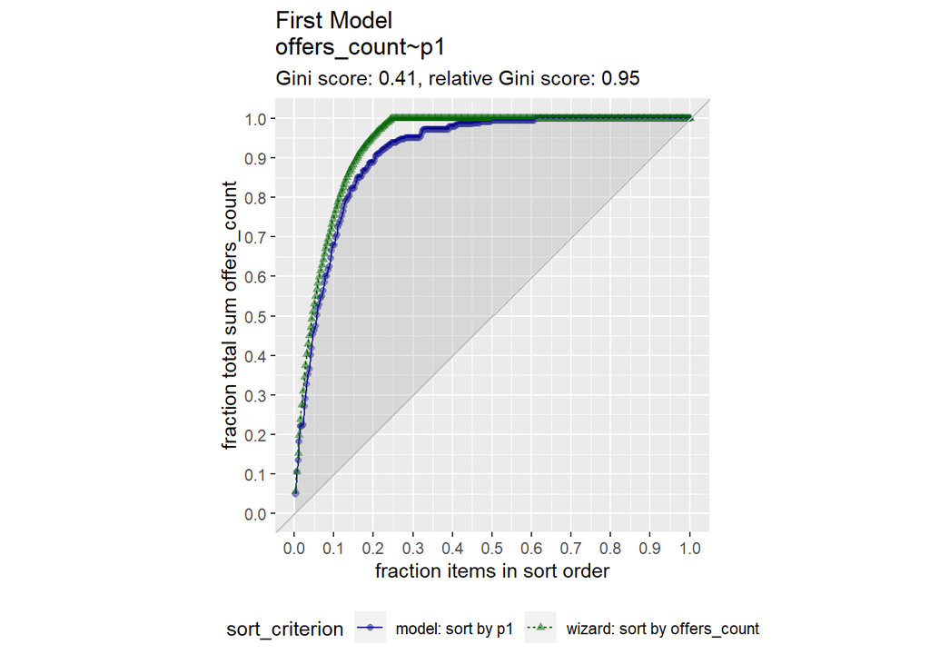

```r
##
GainCurvePlot(
  schools_test,
  "p1",
  "offers_count",
  "First Model")
```

```r
first_mae <- MAE(schools_test$offers_count, schools_test$p1)


# Calculate the RMSE
first_rmse <- schools_test %>%
  mutate(residual = p1 - offers_count) %>%
  summarize(rmse  = sqrt(mean(residual^2)))
```

The mean absolute error of the first model is **6.8365326**.  
The first model’s RMSE is

| rmse |
| --- |
| 10.86938 |

## Second Model

This second model is constructed using a Quasi-Poisson regression. These specific models are used when a count variable is overly dispersed. One quick test is to see if the variance (**588.9338074**) is greater than the mean (**8.4349206**) for `offers_count`.

```r
# Quasipoisson variance is greater than the mean for offers_count
glm_second_model <- glm(offers_count  ~ testers_count + student_count + elaprof + mathprof + coursepassrate, data=schools_train, family=quasipoisson)

summary(glm_second_model)
```

```
##
## Call:
## glm(formula = offers_count ~ testers_count + student_count +
##     elaprof + mathprof + coursepassrate, family = quasipoisson,
##     data = schools_train)
##
## Deviance Residuals:
##      Min        1Q    Median        3Q       Max
## -17.9525   -1.5339   -0.9779   -0.6373    9.6923
##
## Coefficients:
##                  Estimate Std. Error t value Pr(>|t|)
## (Intercept)    -3.8042023  0.6488940  -5.863 5.82e-09 ***
## testers_count   0.0046146  0.0004839   9.537  < 2e-16 ***
## student_count   0.0024473  0.0002893   8.460  < 2e-16 ***
## elaprof        -0.0128340  0.0041142  -3.119  0.00185 **
## mathprof        0.0608657  0.0039056  15.584  < 2e-16 ***
## coursepassrate  0.0226981  0.0071408   3.179  0.00152 **
## ---
## Signif. codes:  0 '***' 0.001 '**' 0.01 '*' 0.05 '.' 0.1 ' ' 1
##
## (Dispersion parameter for quasipoisson family taken to be 4.730181)
##
##     Null deviance: 39950.3  on 1259  degrees of freedom
## Residual deviance:  6278.5  on 1254  degrees of freedom
## AIC: NA
##
## Number of Fisher Scoring iterations: 6
```

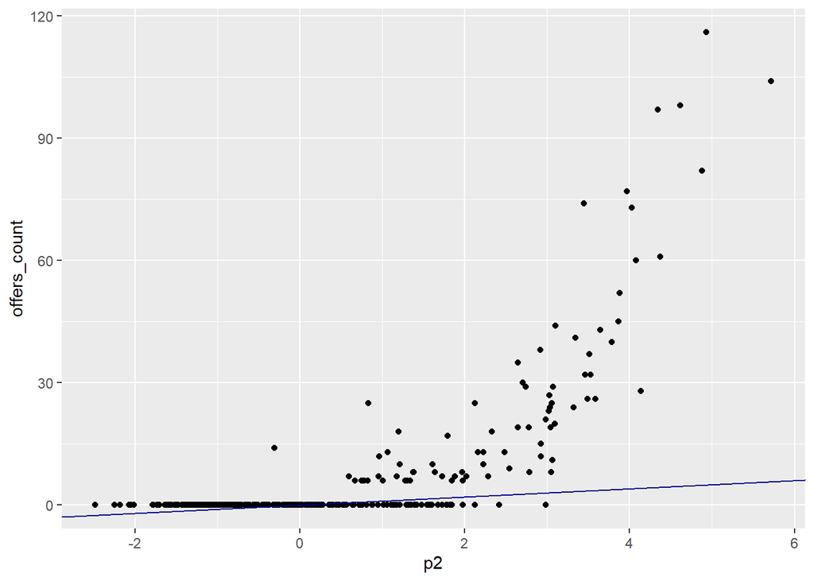

```r
## Create the prediction column based on the model
schools_test$p2 <- predict(glm_second_model, newdata=schools_test)


# Calculate the MAE
second_mae <- MAE(schools_test$offers_count, schools_test$p2)


# Calculate the RMSE
second_rmse <- schools_test %>%
  mutate(residual = p2 - offers_count) %>%
  summarize(rmse  = sqrt(mean(residual^2)))

# Plot predictions vs cnt (pred on x-axis)
ggplot(schools_test, aes(x = p2, y = offers_count)) +
  geom_point() +
  geom_abline(color = "darkblue")
```

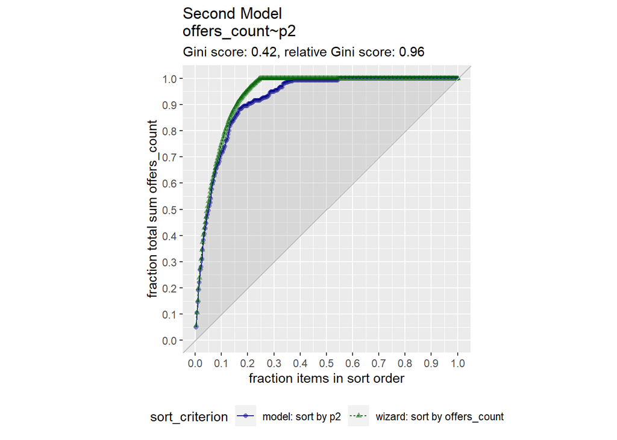

```r
##
GainCurvePlot(
  schools_test,
  "p2",
  "offers_count",
  "Second Model")
```

The mean absolute error of the second model is **6.673356**.  
The second model’s RMSE is

| rmse |
| --- |
| 17.17431 |

## Third Model

The third model attempts to compensate for an excessive number of zeroes. A zero-inflation test is performed on the second model to see if this is the case. This model will employ zero-inflation regression.

```r
# Zero Inflation test for glm_second_model
check_zeroinflation(glm_second_model)
```

```
## # Check for zero-inflation
##
##    Observed zeros: 953
##   Predicted zeros: 452
##             Ratio: 0.47
```

```
## Model is underfitting zeros (probable zero-inflation).
```

```r
zip_model <- zeroinfl(offers_count  ~ testers_count + student_count + elaprof + mathprof + coursepassrate, data = schools_train)

summary(zip_model)
```

```
##
## Call:
## zeroinfl(formula = offers_count ~ testers_count + student_count + elaprof +
##     mathprof + coursepassrate, data = schools_train)
##
## Pearson residuals:
##      Min       1Q   Median       3Q      Max
## -9.15246 -0.18978 -0.05793 -0.02208  7.88307
##
## Count model coefficients (poisson with log link):
##                  Estimate Std. Error z value Pr(>|z|)
## (Intercept)     1.0516479  0.2225555   4.725 2.30e-06 ***
## testers_count   0.0075520  0.0002356  32.048  < 2e-16 ***
## student_count  -0.0008180  0.0001434  -5.705 1.16e-08 ***
## elaprof        -0.0088870  0.0018667  -4.761 1.93e-06 ***
## mathprof        0.0325666  0.0017960  18.133  < 2e-16 ***
## coursepassrate -0.0007899  0.0023219  -0.340    0.734
##
## Zero-inflation model coefficients (binomial with logit link):
##                  Estimate Std. Error z value Pr(>|z|)
## (Intercept)    13.3749090  2.2631489   5.910 3.42e-09 ***
## testers_count  -0.0595986  0.0071053  -8.388  < 2e-16 ***
## student_count  -0.0005538  0.0019960  -0.277 0.781452
## elaprof        -0.0223664  0.0199567  -1.121 0.262397
## mathprof       -0.0610413  0.0179027  -3.410 0.000651 ***
## coursepassrate -0.0538042  0.0232936  -2.310 0.020898 *
## ---
## Signif. codes:  0 '***' 0.001 '**' 0.01 '*' 0.05 '.' 0.1 ' ' 1
##
## Number of iterations in BFGS optimization: 16
## Log-likelihood: -1748 on 12 Df
```

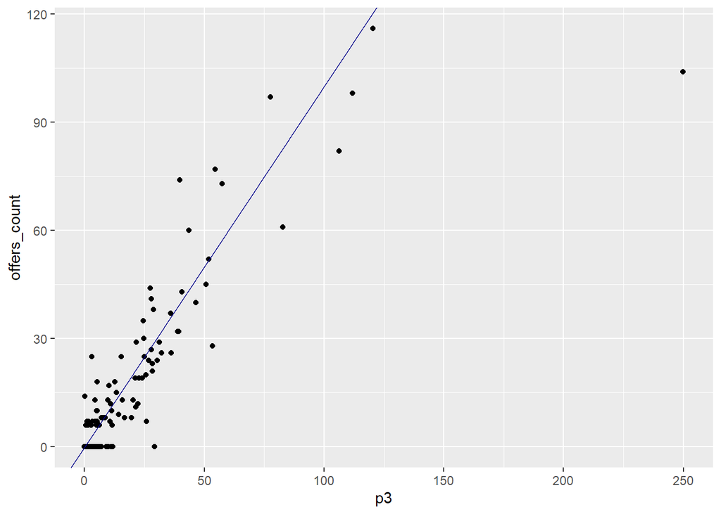

```r
## Create the prediction column based on the model
schools_test$p3 <- predict(zip_model, newdata=schools_test)


# Calculate the MAE
third_mae <- MAE(schools_test$offers_count, schools_test$p3)


# Calculate the RMSE
third_rmse <- schools_test %>%
  mutate(residual = p3 - offers_count) %>%
  summarize(rmse  = sqrt(mean(residual^2)))

# Plot predictions vs cnt (pred on x-axis)
ggplot(schools_test, aes(x = p3, y = offers_count)) +
  geom_point() +
  geom_abline(color = "darkblue")
```

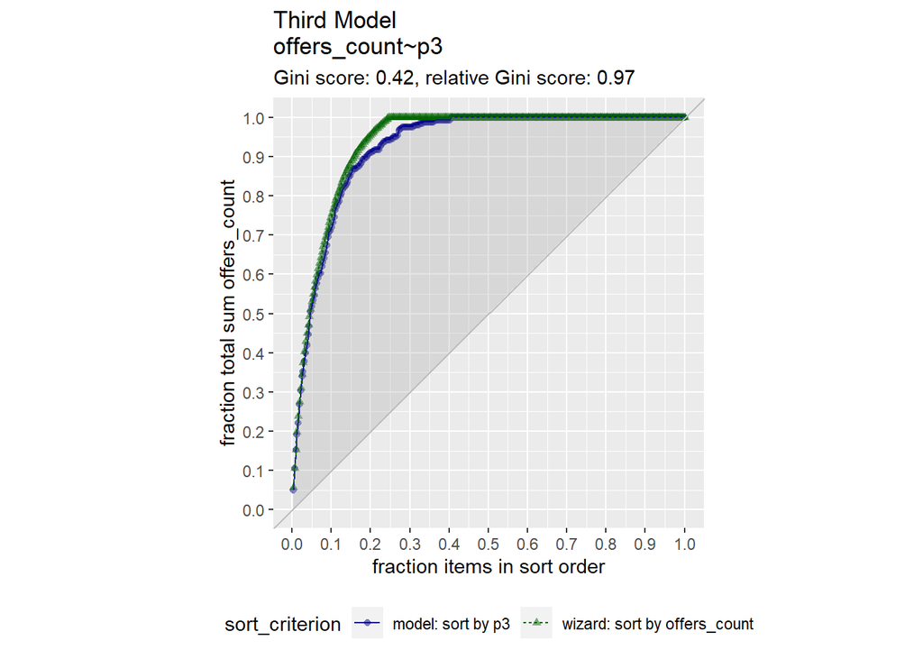

```r
##
GainCurvePlot(
  schools_test,
  "p3",
  "offers_count",
  "Third Model")
```

| rmse |
| --- |
| 9.921071 |

## Comparison of AIC Measures

The following is a comparison of the three models that were created in terms of AIC. Note for Quasi-Poisson regressions there is no AIC reported.

```r
AIC(first_model, glm_second_model, zip_model)
```

|  | df | AIC |
| --- | --- | --- |
| first_model | 7 | 9941.780 |
| glm_second_model | 6 | NA |
| zip_model | 12 | 3519.196 |

# Results

# Summary

Overall, from this study, I would recommend for additional aid for improving NYS proficiency in ELA and math for all students. This study did not examine the racial demographic of students. However, in future studies, I would encourage that such demographics be ignored and that researchers look at NYS proficiency rates. In addition, as these rates are examined, I would recommend researchers look at the impact of the city’s Gifted & Talented programs. Because lack of diversity is a problem in Specialized High Schools, additional research needs to examine diversity in the early childhood education, specifically the Gifted & Talented programs. Further study should also examine SHSAT awareness in minority communities: perhaps, lack of participation is another inhibiting factor for lack of diversity.

An additional recommendation would be to consider providing additional resources for SHSAT preparation. Perhaps lack of quality test prep programs would provide students the opportunity to catch up to NYS proficiency standards.

# Appendix

## Code

The code used for this project can be found at these locations:

- GitHub for Project: https://github.com/logicalschema/spring2022/tree/main/data698
- GitHub for Shiny App: https://github.com/logicalschema/spring2022/tree/main/data698/shinyapp/NYC_DOE_SHSAT
- GitHub for Python App: https://github.com/logicalschema/specialized-hs

## Links

- [YouTube Presentation](https://youtu.be/DoopFVvXSMU)
- [Plotly App](https://sslee-specializedhs.azurewebsites.net/)
- [Shiny App](https://logicalschema.shinyapps.io/NYC_DOE_SHSAT/)
- [RPubs Site](https://rpubs.com/logicalschema/data698)

## Bibliography

Almarode, Subotnik, R., & Lee, G. M. (2016). What Works: Lessons From a Research Study of Specialized Science High School Graduates. Gifted Child Today Magazine, 39(4), 185–190. https://doi.org/10.1177/1076217516662096

Chang, W. (2013, January 1). Cookbook for R. Retrieved April 5, 2022, from http://www.cookbook-r.com/Graphs/Multiple_graphs_on_one_page_(ggplot2)/

Corcoran, S., & Baker-Smith, C. (2015). Pathways to an Elite Education: Exploring Strategies to Diversity NYC’s Specialized High Schools. Institute for Education and Social Policy, and Research Alliance for New York City Schools.

Fadilla, & Usmeldi. (2020). Preliminary study for development of teacher’s Books oriented research-based learning on science lesson in Junior High School. Journal of Physics. Conference Series, 1481(1). https://doi.org/10.1088/1742-6596/1481/1/012068

Nwanganga, Fred; Chapple, Mike. Practical Machine Learning in R (Kindle Locations 3605-3681). Wiley. Kindle Edition.

Reeves, Richard V., and Ashley Schobert. “Elite or Elitist? Lessons for Colleges from Selective High Schools.” Brookings, Brookings, 9 Mar. 2022, https://www.brookings.edu/research/elite-or-elitist-lessons-for-colleges-from-selective-high-schools/.

Taylor, Jonathan James, “Policy Implications of a Predictive Validity Study of the Specialized High School Admissions Test at Three Elite New York City High Schools” (2015). CUNY Academic Works. https://academicworks.cuny.edu/gc_etds/1154

Waran, R. (2021, June 17). Deploying dash apps on azure with windows. Resonance Analytics. Retrieved March, 2022, from https://resonance-analytics.com/blog/deploying-dash-apps-on-azure

Wickham, Hadley; Grolemund, Garrett. R for Data Science . O’Reilly Media. Kindle Edition.

[^1]: https://www.brookings.edu/research/elite-or-elitist-lessons-for-colleges-from-selective-high-schools/
[^2]: https://nyuscholars.nyu.edu/en/publications/pathways-to-an-elite-education-exploring-strategies-to-diversity-